# EDA FINAL REPORT

Denis Golovenko

31 05 2020

## Stations. stations, stations.

*(all of the coding answers and prooves are in Part1(Questions).R)*

**2.A simple ‘for’ loop, that counts number of stations by countries.**

```
##     Country Stations
##  1:      FR        2
##  2:      CZ        5
##  3:      SK        2
##  4:      SE       27
##  5:      DE       78
##  6:      IS        1
##  7:      NL        3
##  8:      HU        1
##  9:      PL        1
## 10:      RS        2
## 11:      GB        5
## 12:      NO       26
## 13:      RO        3
## 14:      FI       16
## 15:      DK        5
## 16:      CH       22
## 17:      RU        7
## 18:      LT        1
## 19:      UA        1
```

**3.As in previous question, I count stations with a help of ‘for’ loop.**

```
##                    River Stations
##   1:               LOIRE        2
##   2:          ELBE RIVER        5
##   3:       DIVOKA ORLICE        1
##   4:              MORAVA        2
##   5:        DANUBE RIVER       13
##  ---
## 149:     NEMUNAS - NEMAN        1
## 150:   OKA (TRIB. VOLGA)        1
## 151:              VYATKA        1
## 152: BELAYA (TRIB. KAMA)        1
## 153:               DESNA        1
```

**4.Here we can see average, maxima and minima of stations positon parameters.**

```
##     AvgLat   AvgLon   AvgAlt
## 1: 54.2638 13.50659 229.1394
```

```
##    MaxLat   MaxLon MaxAlt
## 1:  70.07 56.84958   1076
```

```
##    MinLat   MinLon MinAlt
## 1:   44.7 -19.3883      0
```

**5.Using R syntax we can see what are the recording duration parameters(in years).**

```
##       AvgRL MaxRL MinRL
## 1: 101.8798   208    80
```

## Rivers runoff exploration

**1.Here please have a look at runoff statistics I got, number of stations is to big, to look readble in plot, but still we can see the distribution of values(e.g. mean discharge).**

```
##           id mean   sd     min   max        cv                 sname
##   1: 6123100  799  910 -999.00  5750 1.1389237              MONTJEAN
##   2: 6140400  313  277   34.00  4600 0.8849840                 DECIN
##   3: 6140700    3    4    0.00   106 1.3333333                 NEKOR
##   4: 6142100   16   45 -999.00   567 2.8125000            MORAVICANY
##   5: 6142120   59   64    2.46   850 1.0847458             STRAZNICE
##  ---
## 198: 6970250 1032 3709 -999.00 30600 3.5939922            UST-PINEGA
## 199: 6970500  621 1027 -999.00  9450 1.6537842      MALONISOGORSKAYA
## 200: 6970705  157  247   14.00  2020 1.5732484 YAKSHA (YAKSHINSKAYA)
## 201: 6972430 2444  683  460.00  4400 0.2794599         NOVOSARATOVKA
## 202: 6974150  487  492 -999.00  6822 1.0102669           SMALININKAI
```

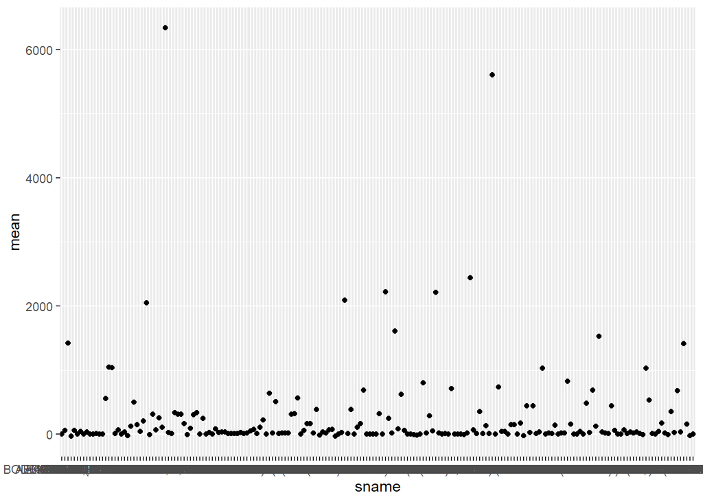

**2.And also some estimated statistics. Spent some time on this, because it was pretty unclear for me what am I supposed to do, hope, I got it right.(Plot is for mean/high runoff)**

```
##                      sname      id         MH          ML
##   1:              MONTJEAN 6123100 0.13895652 -0.79979980
##   2:                 DECIN 6140400 0.06804348  9.20588235
##   3:                 NEKOR 6140700 0.02830189         Inf
##   4:            MORAVICANY 6142100 0.02821869 -0.01601602
##   5:             STRAZNICE 6142120 0.06941176 23.98373984
##  ---
## 198:            UST-PINEGA 6970250 0.03372549 -1.03303303
## 199:      MALONISOGORSKAYA 6970500 0.06571429 -0.62162162
## 200: YAKSHA (YAKSHINSKAYA) 6970705 0.07772277 11.21428571
## 201:         NOVOSARATOVKA 6972430 0.55545455  5.31304348
## 202:           SMALININKAI 6974150 0.07138669 -0.48748749
```

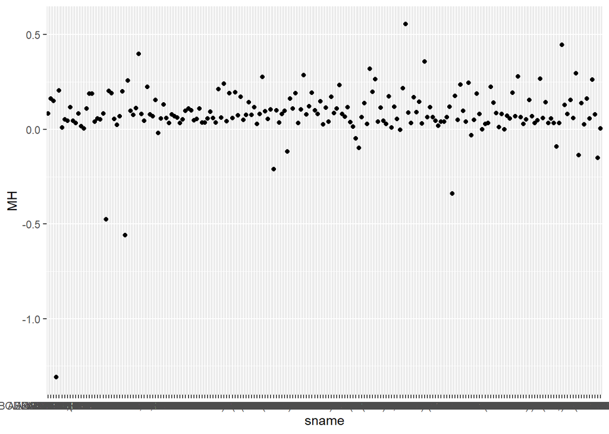

**3.Categories I created were based on the stations position relative to the Europe(Central EU, Western EU etc.) and their landform(Hill, Lowland etc.).**  
Most of the work had been going on paper, I was writting down all the Lon and Lat limits basing on a regular school atlas. The same for the landform values.

```
##                     Station   Lat      Lon Alt     Pos      LF
##   1:               MONTJEAN 47.38 -0.83000   9    West Lowland
##   2:                  BLOIS 47.58  1.33000  66    West Lowland
##   3:                  DECIN 50.79 14.23000 120 Central Lowland
##   4:                  NEKOR 50.07 16.55000  NA Central    <NA>
##   5:             MORAVICANY 49.75 16.96667 244 Central    Hill
##  ---
## 204:            SMALININKAI 55.08 22.57972   7    East Lowland
## 205:                 KALUGA 54.54 36.27056 117    East Lowland
## 206:                  KIROV 58.60 49.65833 103    East Lowland
## 207:                  BIRSK 55.42 55.54278  70    East Lowland
## 208: KOLYCHOVKA (CHERNIGOV) 51.42 31.30000 104    East Lowland
```

```
##           id mean   sd     min   max        cv                 sname     Pos
##   1: 6123100  799  910 -999.00  5750 1.1389237              MONTJEAN    West
##   2: 6140400  313  277   34.00  4600 0.8849840                 DECIN Central
##   3: 6140700    3    4    0.00   106 1.3333333                 NEKOR Central
##   4: 6142100   16   45 -999.00   567 2.8125000            MORAVICANY Central
##   5: 6142120   59   64    2.46   850 1.0847458             STRAZNICE Central
##  ---
## 198: 6970250 1032 3709 -999.00 30600 3.5939922            UST-PINEGA    East
## 199: 6970500  621 1027 -999.00  9450 1.6537842      MALONISOGORSKAYA    East
## 200: 6970705  157  247   14.00  2020 1.5732484 YAKSHA (YAKSHINSKAYA)    East
## 201: 6972430 2444  683  460.00  4400 0.2794599         NOVOSARATOVKA    East
## 202: 6974150  487  492 -999.00  6822 1.0102669           SMALININKAI    East
##           LF
##   1: Lowland
##   2: Lowland
##   3:    <NA>
##   4:    Hill
##   5:    <NA>
##  ---
## 198: Lowland
## 199: Lowland
## 200: Lowland
## 201:    <NA>
## 202: Lowland
```

**4.This part was the most challenging for me.**  
Reading the task for the 100th time, I sill was getting clear what do I need to do here. Part about estimating statistics for the categories confused me most, so here is a result of how I got this.  
**a)Estimation for each station**

```
##           id                 sname         MH          ML  MH_Before  ML_Before
##   1: 6140400                 DECIN 0.06804348  9.20588235 0.07083079  9.1580047
##   2: 6140700                 NEKOR 0.02830189         Inf 0.03119272        Inf
##   3: 6142100            MORAVICANY 0.02821869 -0.01601602 0.07100094 17.5372319
##   4: 6142120             STRAZNICE 0.06941176 23.98373984 0.09851759 15.9758258
##   5: 6142200            BRATISLAVA 0.19941663  3.53620690 0.19869636  3.5234346
##  ---
## 196: 6970250            UST-PINEGA 0.03372549 -1.03303303 0.01272293 -0.3897114
## 197: 6970500      MALONISOGORSKAYA 0.06571429 -0.62162162 0.06805978 -0.6438087
## 198: 6970705 YAKSHA (YAKSHINSKAYA) 0.07772277 11.21428571 0.09865658 11.7227236
## 199: 6972430         NOVOSARATOVKA 0.55545455  5.31304348 0.54553948  5.2182037
## 200: 6974150           SMALININKAI 0.07138669 -0.48748749 0.07209351 -0.4923143
##        MH_After   ML_After
##   1: 0.06912770  3.8173758
##   2: 0.04551160        Inf
##   3: 0.02095679 -0.0118944
##   4: 0.06870805 23.7405862
##   5: 0.20361819  2.7427775
##  ---
## 196: 0.10718469 -3.0470924
## 197: 0.06697287 -0.5785545
## 198: 0.08439818 10.4894886
## 199: 0.63905020  4.4584898
## 200: 0.15150729 -0.4580100
```

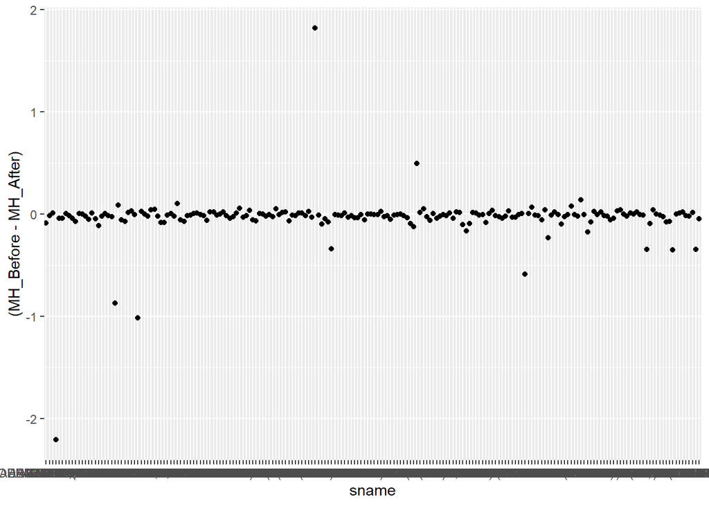

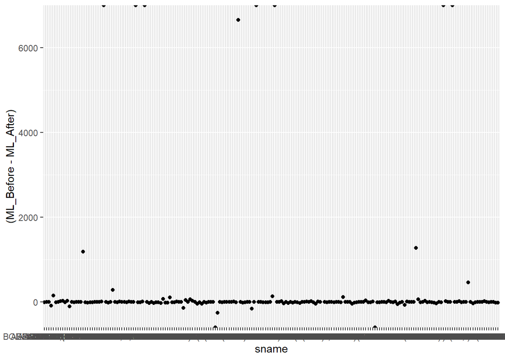

**b)Estimation for the categories**

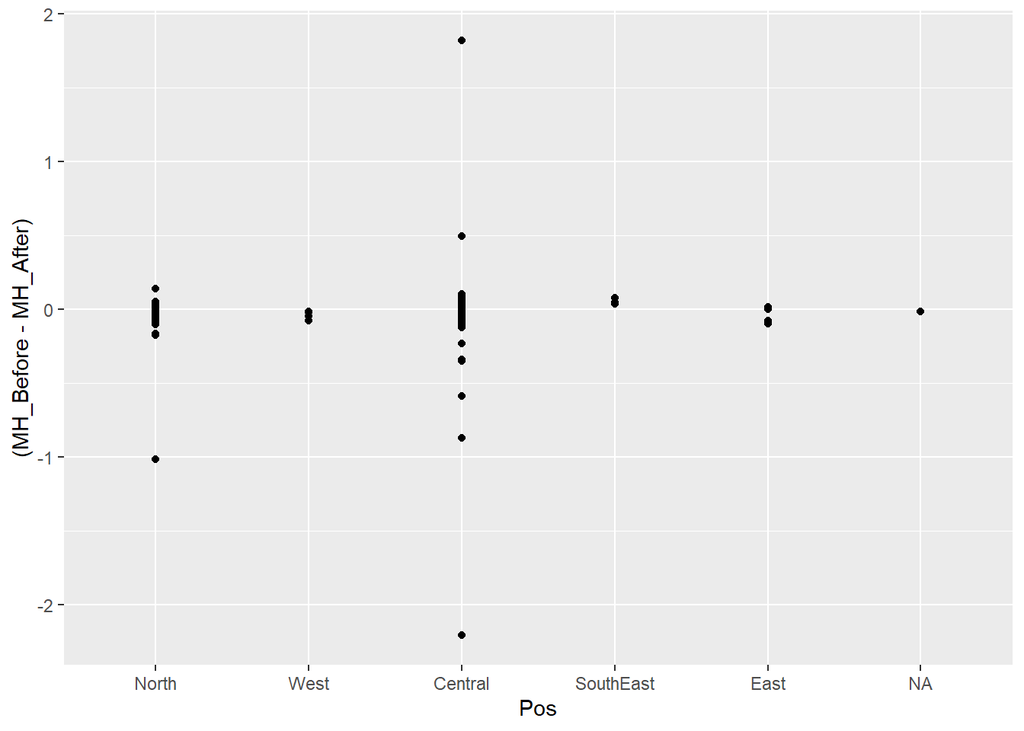

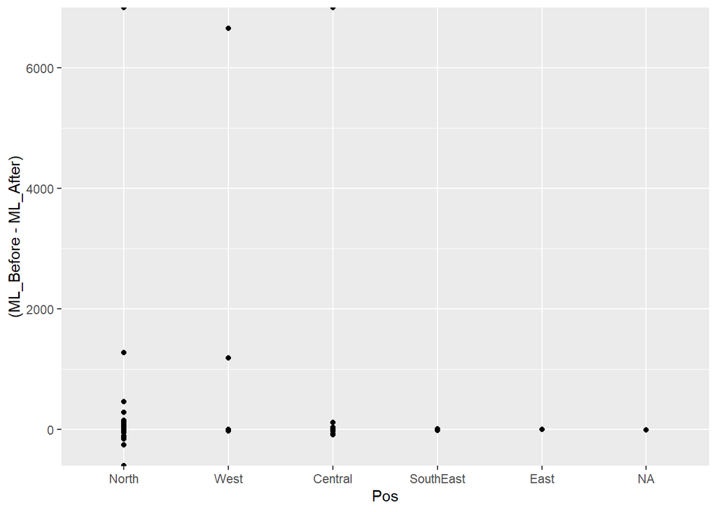

**5.This step had been done many times during the lectures, so aggregating to winter/summer runoff was pretty automatic.**

```
##               id       date value year year_type month Season
##       1: 6123100 1963-01-01   770 1963    before     1 Winter
##       2: 6123100 1963-01-02   765 1963    before     1 Winter
##       3: 6123100 1963-01-03   810 1963    before     1 Winter
##       4: 6123100 1963-01-04  1040 1963    before     1 Winter
##       5: 6123100 1963-01-05  1250 1963    before     1 Winter
##      ---
## 7425133: 6974150 2009-12-27   495 2009     after    12 Winter
## 7425134: 6974150 2009-12-28   551 2009     after    12 Winter
## 7425135: 6974150 2009-12-29   612 2009     after    12 Winter
## 7425136: 6974150 2009-12-30   702 2009     after    12 Winter
## 7425137: 6974150 2009-12-31   693 2009     after    12 Winter
```

As an quick example here is a data table with winter runoff after year 1980.

```
##           id year_type       value
##   1: 6140400     after  366.984869
##   2: 6140700     after    4.152975
##   3: 6142100     after    6.622716
##   4: 6142120     after   60.163185
##   5: 6142200     after 1746.776780
##  ---
## 197: 6970250     after  804.203360
## 198: 6970500     after  140.740779
## 199: 6970705     after   35.488920
## 200: 6972430     after 1741.850416
## 201: 6974150     after  472.922821
```

**6.A map of stations location**  
When I got to this step, I decided to take a break for a week, because map were not working for me at all. I’m still not sure about a right solution for this, my pc has a lot of calculating resources, even though popups for 200+ stations are not working, so what I got is just a map of their locations with names of stations.

[interactive chart not shown]

## Striking while the iron is hot.

*Firstly maps didn’t work for me, so I didn’t choose any stations and took 5 random. I got an unique coding solution for all the task. Later, while I was writting this report, maps worked out! Stations I chosed then are: REYKJAFOSS(Island), POLMAK(Norway), CEATAL IZMAIL(Romania/Ukraine), KOELN(Germany), YAKSHA(Russia).*

### 1.Chosen stations

**-REYKJAFOSS(Island)**  
**Main aspect:** Water sources impact.  
I took this station, obviously, because it’s isolated from the others by water, and based on north. So we can explore how cold waters affect runoff. Human impact is not that big there.

**-POLMAK(Norway)**  
**Main aspect:** Glaciers impact  
The most north stations. Just to see if there is any special impact from glaciers, and if there is, exploring runoff we can say if glaciers are melting a lot since time or not.

**-CEATAL IZMAIL(Romania/Ukraine)**  
**Main aspect:** Warm climat and tourism.  
The most south station, closest to the warm Black Sea. The is no cold long winter in this area, let’s explore how runoff has changed there. Human impact is more than average, bacause of a tourism. People go there for a vacation not only in summer, but in winter too, so waters are affected by people during whole year. But it’s not direct impact, and comes mostly from the sea.

**-KOELN(Germany)**  
**Main aspect:** Human impact.  
This station was chosen because of the interest to the human impact to runoff. Looking at human density map, Koln city was chosen as one of the densiest city(2668 human/km^2). Also impact from tourists. And the main reason of choosing KOELN station is that it’s located at the center of city, human impact is going really big.

**-YAKSHA(Russia)**  
**Main aspect:** No human impact.  
No, I didn’t choose this station because I’m Russian. I did this because this station is isolated not only from people but from water resources too. All river feeding is coming only from ground waters and precipitation. It must rain a lot, because of the Ural mountain stopping the air masses. So data from this station will show us how precipitation level might have changed since time.

### 2.Seasonality

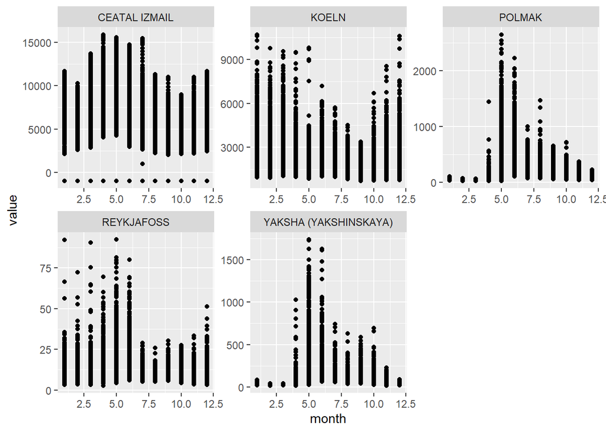

**b)Monthly seasonality before 1980**

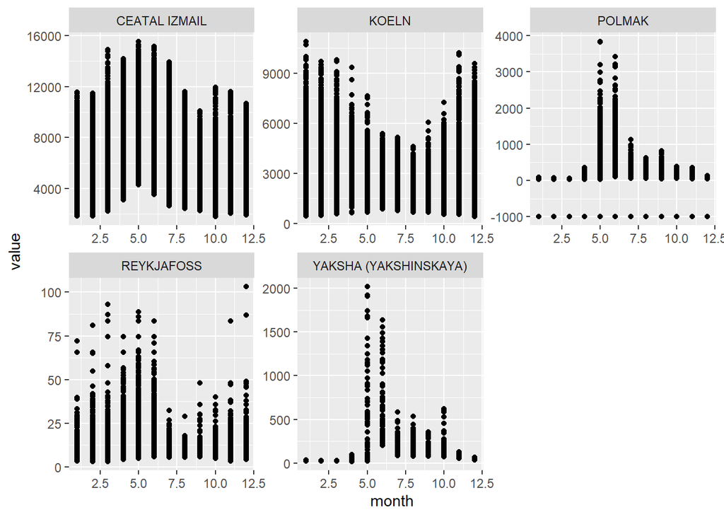

# 3.Correlation matrix

*Here, I noticed that the change in runoff for:*  
-Stations impacted mostly only form water/ice almost don’t correlate.(REYKJAFOSS and POLMAK)  
-Station impacted from people anti-correlate with station without human impact.(CEATAL IZMAIL,KOELN and YAKSHA)  
-Interesting that, REYKJAFOSS and YAKSHA stations correlate the most, even though in common they have only the north location and the smallest human impact. But they almost don’t correlate with POLMAK station, that is also has north location, but has much more human impact.  
**Correlation matrix plot for data after year 1980**

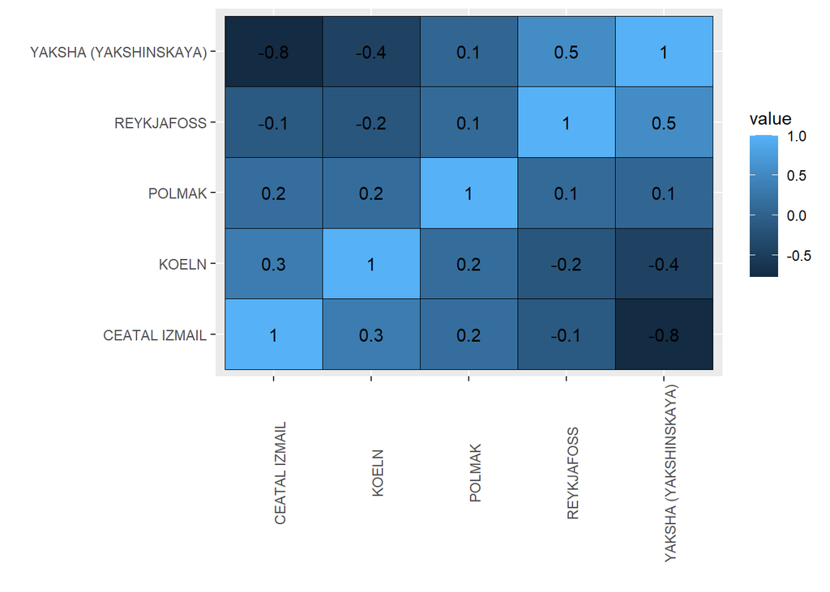